# Reproducibility of “Characterizing Political Fake News in Twitter”

Andy De La Fuente, Anmol Srivastava, Juan Solorio, Maggie Weatherly, Matt Rhodes

15 March, 2020

# Introduction

The research our team attempted to reproduce was “Characterizing Political Fake News in Twitter By Its Meta-Data” by Julio Amador Dıaz Lopez, Axel Oehmichen, and Miguel Molina-Solana (2017). The paper’s fundamental claim is that there are differences around the exposure and characteristics of fake Twitter accounts versus other accounts, as well as the tone of the content. Their research and curated data is available at https://github.com/alumag/ADAFake.

Dıaz Lopez, Julio Amador. 2017. “Characterizing Political Fake News in Twitter by Its Meta-Data.” *arXiv Preprint arXiv:1712.05999v1*.

The original research group pulled Twitter data, over 1.5M tweets were collected related to the day of the election of Donald Trump as 45th President of the United States of America. The research group, focused on tweets that went viral (those with large number of re-tweets), manually curated these to differentiate between “Fake New” and “Other” for each tweet. Our team focused on reproducing Figures 4, 6, 7, 9, and 12 as well as Table 1 in order to test the original hypotheses of observable significant difference in meta-data between those accounts characterized as “Fake News” and those characterize as “Other”. Primarily, we are focused on testing the claims of difference among the distribution of number of hashtags (*num_hashtags*), distribution of URLs (*num_urls*), and the distributions of user friends and followers (*user_friends_count*,*user_followers_count*).

Our project and supporting code can be found in the git repository at https://github.com/mweath/replication_project_598.

# Table 1

## Original Table 1

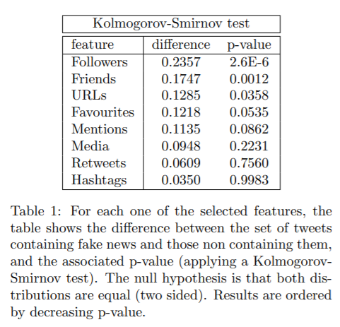

## Replication of Table 1

```
##                   names differences       p_vals
## 1  user_followers_count  0.23571393 1.286269e-06
## 2    user_friends_count  0.17468637 5.817257e-04
## 3              num_urls  0.12847582 1.778299e-02
## 4 user_favourites_count  0.12180200 2.673583e-02
## 5          num_mentions  0.11349212 4.309171e-02
## 6             num_media  0.09475478 1.117092e-01
## 7         retweet_count  0.06089174 4.044762e-01
## 8          num_hashtags  0.03501136 7.413773e-01
```

## Process of Table 1 Replication

For the process of recreating table 1 of this paper, we separated the data into two separate matrices where matrix 1 had all of the tweets that were labeled false and the other matrix had all the tweets that were labeled true. Next, we identified the columns that matched the individual rows in the original feature column and then ran the ks.test function provided by R. Samples were drawn from the same column but different matrices, (i.e. num_retweets from False and num_retweets from True) We assumed that the same two sided greater than hyptohesis was ran for their test but realized that they used a combination of both less than and greater than for the alternative for their two sided hypothesis test. The thing that we chose to vary in this reproduction was the actual Kolmogorov Smirnov Test, in the paper the authors said they ran the actual test which we interpreted as them coding the test and running it (they never specify) but we just called an R function. We also assumed that this didn’t matter since its the same test and found that we got the same values for differneces but different values for the p-value which makes us question their numbers. In the end if they used a signifcance level of 0.05 (which they didn’t specify) then all of the conclusions from the p-value are the same except for number of mentions and user favorite count.

# Figure 4

## Original Figure 4

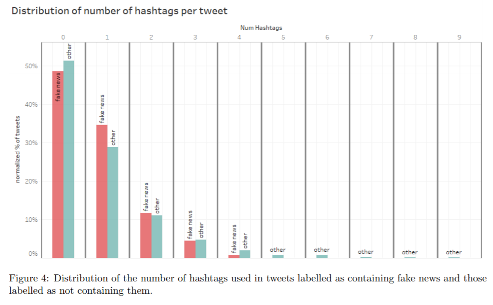

## Replication of Figure 4

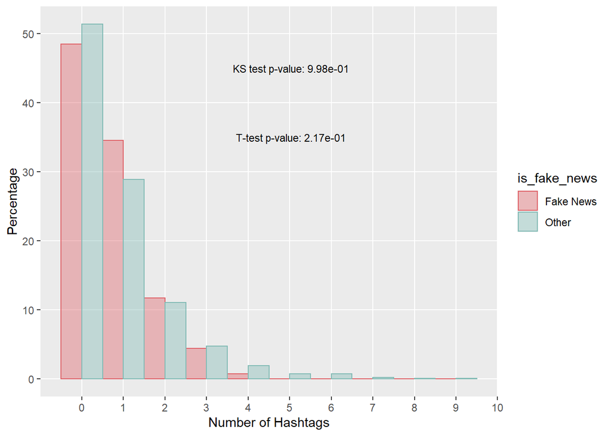

## Process of Figure 4 Replication

Figure 4 was a relatively simple figure to replicate. Using the supporting figure description, x-axis title and y-axis title, it was fairly straightforward when it came to replication. In the paper, “Characterizing Political Fake News in Twitter”, Figure 4 depicts a histogram of all tweets in the dataset, segmented into two groups, Fake News and Other, and then binned by the number of hashtags they contained. In traditional histograms, the y-axis corresponds to county, however, in Figure 4, the y-axis corresponds to the percentage of tweets of a group (Fake News or Other) that fell into that specific bin of number of hashtags. It was then easy to then apply ggplot and geom_histogram functions on the dataset to get an almost identical figure to the one produced in the paper. Since the style of the two figures vary slightly, it is proably safe to assume that the authors of the paper used different or additional libraries to generate Figure 4.

Additionally, we supported our replication of Figure 4 with calculation of p-values for both *Welch T-test* and *Kolmogorov-Smirnov test* into the figure, calculated through the R functions *t.test* and *ks.test*. Both tests show a large p-value which supports the author’s conclusion that there is no statistical difference between the average number of hashtags in our two groups of tweets, “Fake News” and “Other”.

# Figure 6

## Original Figure 6

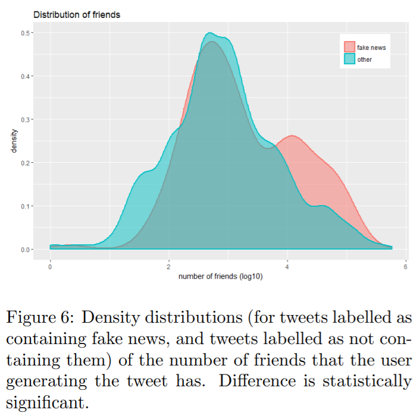

## Replication of Figure 6

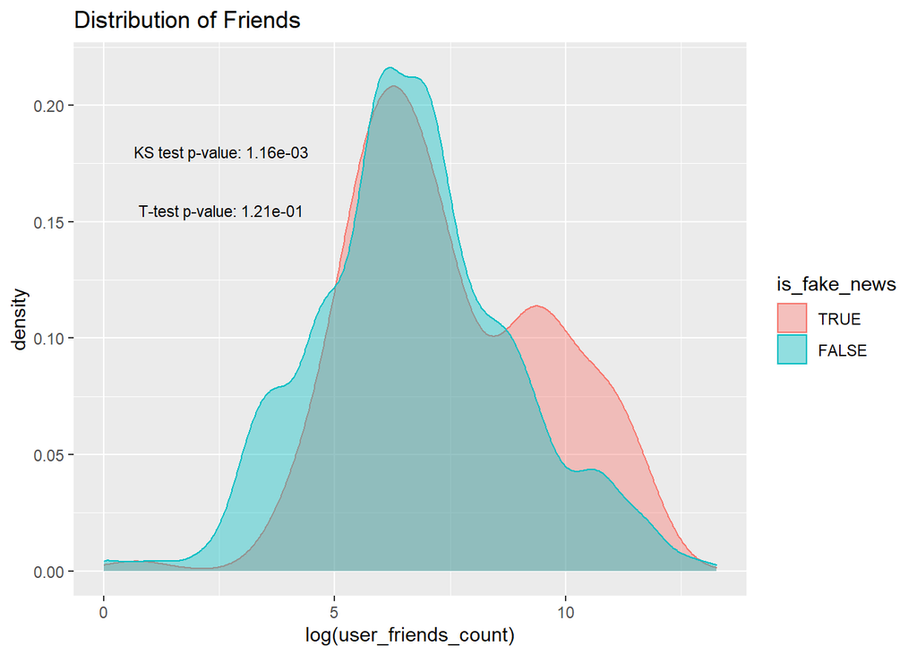

## Process of Figure 6 Replication

This figure, according to the original paper, displays a density plot of the number of friends for tweets classified as fake news versus those that were not, and captures a statistically significant difference. The initial step in replicating this was to plot these distributions directly. Using ggplot, two separate distribution bar graphs were generated, one for each of the categories. Initially this seemed to be very far off from the original results, but this was because an unaltered scale was used. After representing the number of friends on a log scale, the results were similar. Seeing a rough match with what the orignial figure contained, the next step was to determine how the authors went about ‘smoothing’ the distribution plots. After exploring some options for kernel density estimation, the ggplot estimation produced results precisely like those the original authors did.

Beyond this, some experimentation was done with ggplot styling options to achieve the same look for the finished figure, which required to order the categories in the reverse of the default so that the distributions would render exactly how they are in the original figure.

# Figure 7

## Original Figure 7

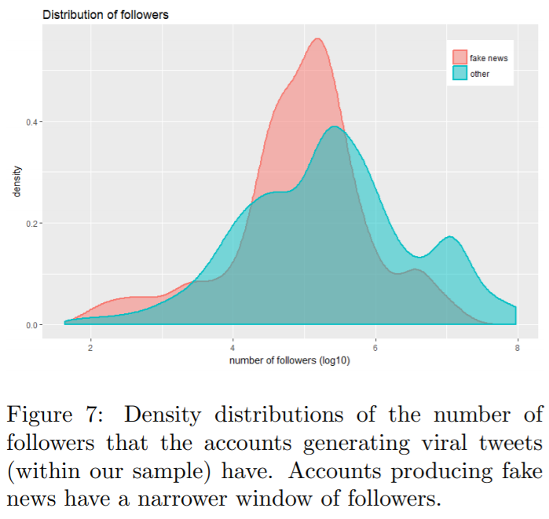

## Replication of Figure 7

Replication of figure 7, displaying density distributions of the number of followers that the accounts generating viral tweets. Showing statistical significance in the difference between the distributions.

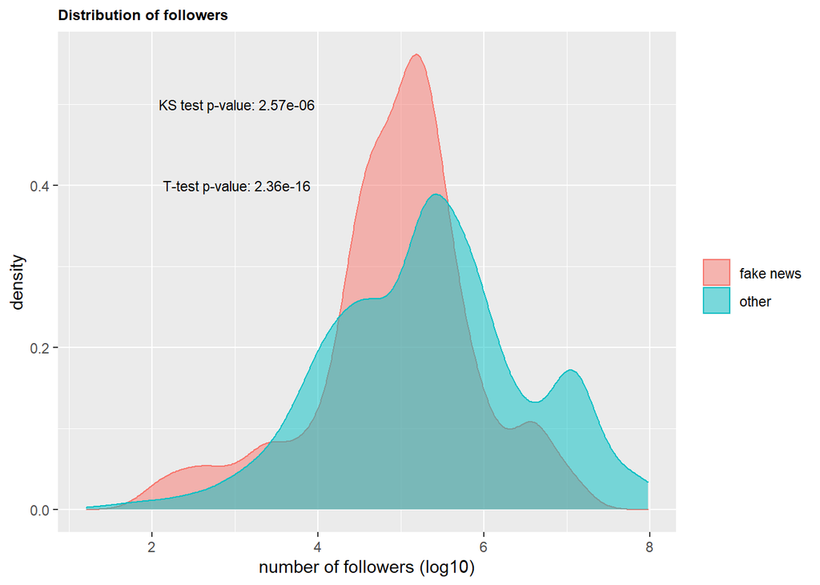

## Process of Figure 7 Replication

In replicating Figure 7, which displayed a density distribution of followers between accounts labeled as Fake News or Other from the currated data source, there were a few data manipulation that were needed to replicate the figure through the ggplot2 library in R. Moreover, the original purpose for the figure is to graphically show statistically significant difference between the distributions of labeled accounts.

The first, the data was read from the “Electionday_tweets_clean.csv” data file provided by (Dıaz Lopez 2017) research and passed into the *ggplot* and *aes* functions. Through the aes function, the *x* aes value given the **user_followers_count** and the *fill* value (which splits the data by category) was passed a new engineered column **FakeNewsLabel**, which provided the appropiate labels of “Fake News” and “Other” from the boolean values given by the **is_fake_news** column. Next the geom_density function is added the ggplot code, defining the type of graph that will be created. To the code we then have to make a log transformation to the x-axis, as the data is too widely distributed for the number of followers for the various accounts. The log transform is accomplished by the *scale_x_continuous(trans = ‘log10’)* command. This provides with the basic plot that replicates the output similar to that of the original Figure 7 (Dıaz Lopez 2017).

Dıaz Lopez, Julio Amador. 2017. “Characterizing Political Fake News in Twitter by Its Meta-Data.” *arXiv Preprint arXiv:1712.05999v1*.

Dıaz Lopez, Julio Amador. 2017. “Characterizing Political Fake News in Twitter by Its Meta-Data.” *arXiv Preprint arXiv:1712.05999v1*.

Additional aesthetic aspects were added to our replication, such as the addition of p-values for both a *Welch T-test* and a *Kolmogorov-Smirnov test* into the figure, calculated through the R functions *t.test* and *ks.test*. Both test show a p-value of statistical significance for the distribution of followers between “Fake News” and “Other” accounts.

# Figure 9

## Original Figure 9

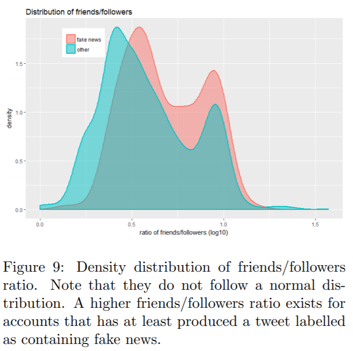

## Replication of Figure 9

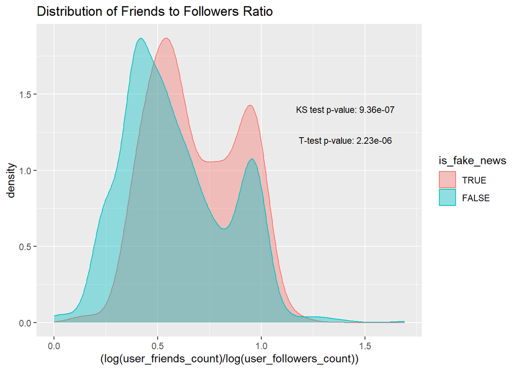

## Process of Figure 9 Replication

Being a very similar figure to figure 6, figure 9 was replicated by the same process. Variations on the ‘ratio’ calculation for ‘friends to followers’ were experimented with, including a direct ratio and a log of the ratio. However, the calculation that yielded the scale most like the original figure was the ratio of the logs of each value.

Figure 9, like 6 and 7, is also used to claim a difference in distributions. For this reason, p values were generated for two different kinds of tests, and the results validate the original claim. Despite not having a level of significance for these tests from the authors, the p values are small enough that any commonly used significance level would have resulted in the same conclusion. Due to the fact that these tests were being used on the log transform of values for this figure, tweets with a value of 0 for either friends or followers had to be removed, as this would result in non numeric values which the T Test could not handle.

# Figure 12

## Original Figure 12

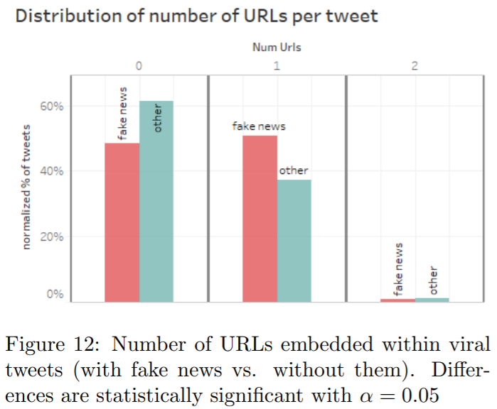

## Replication of Figure 12

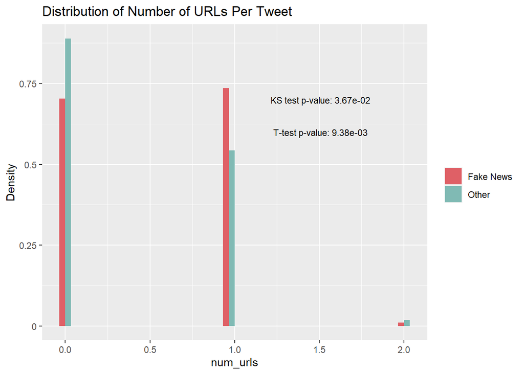

## Process of Figure 12 Replication

In the original paper, Figure 12 captures the distribution of the portion of tweets with different amounts of URLs embedded within. A histogram was used to represent the distributions for tweets classified as ‘fake news,’ and not, side-by-side.

Replicating this figure proved to be complicated. Note that the replicated figure features the exact same distribution bars/curve as in the original figure. That is, the relationships between the portions (for any given number of URLs) match the relationships in the original chart.

There are, however, certain differences. Notably, the x-axis is scaled differently (despite the bars painting an identical picture). This is likely because the original creators factored the num_urls variable into a discrete one. Here, programming errors mandated that num_urls be treated as a continuous one (hence the extraneous x-axis ticks).

Additionally, the scale on the y-axis is slightly shifted (upwards) in the replicated figure, which initially suggests that mis-replication. Instead, the original authors must have used some unique function to yield the “normalized percent of tweets” that was not available here. Note that all normalization functions in geom_histogram() have the same intent: to produce a density plot where the sum area under the bars of one distribution is 1. For instance, the red (fake-news) bars in the original figure indeed sum to 1. While that exact density-calculating function was not used, this property is preserved in the new figure. Also, the pattern made by the bars in the original figure is also preserved, and so are the conclusions that can be drawn from it. So, while the process of replication differed, the results are nigh-identical and statistically sound.

Note that differences are statistically significant at alpha = 0.05, as expected.